# Measuring schroeder periods

- Show All Code
- Hide All Code
- View Source

Fine scale acoustic perception in zebra finches

Author

Marcelo Araya-Salas

Published

February 18, 2025

Source code and data found at https://github.com/maRce10/acoustic-fine-features-zebra-finch

# 1 Purpose

- Detect start and end of periods in a schroeder using amplitude cross-correlation
- Compare methods for measuring fine scale structural variation and periodicity in schroeders

# 2 Report overview

- Synthetizing schroeders
- Detecting periodicity
- Measuring schroeder dissimilarity
- Takeaways

```r
source("~/Dropbox/Projects/geographic_call_variation_yellow-naped_amazon/scripts/MRM2.R")

warbleR_options(parallel = 22)

wave_col <- viridis(10)[7]
```

# 3 Synthetizing schroeders

## 3.1 Function to make schroeders

```r
qwindpc <- function(rftime, srate, sig) {
    ramppts <- round((rftime/1000) * srate)
    hold1 <- seq(0, 1, length.out = ramppts + 1)
    onramp <- sin(0.5 * pi * hold1)^2
    offramp <- cos(0.5 * pi * hold1)^2
    steady <- rep(1, length(sig) - (2 * ramppts) - 2)
    wind <- c(onramp, steady, offramp)

    if (length(wind) > length(sig)) {
        print("Window not applied, block too short for window")
    } else {
        sig <- wind * sig
    }

    return(sig)
}


make_schroeder <- function(samp.rate = 44100, f0, dur = 1000, save.wave = FALSE,
    plot = TRUE, n.components, scalar = 1, color = wave_col, path = ".",
    file.name = NULL, random.start = FALSE, mfrow = c(2, 1), par = TRUE,
    cex.oscillo = 1, ...) {

    # duplicate duration if starting randomly
    dur.mult <- if (random.start)
        2 else 1

    # set time instances at which samples will be 'taken'
    t <- seq(1/samp.rate, 1, by = 1/samp.rate)
    sumwavepos <- rep(0, samp.rate)

    durpts <- round((dur * dur.mult/1000) * samp.rate)

    phase <- rep(0, n.components)
    amplin <- rep(1, n.components)
    f <- rep(0, n.components)

    Ns <- 1:n.components

    for (n in Ns) {
        compnum <- n
        phase[compnum] <- scalar * pi * compnum * (compnum - 1)/n.components
        f[n] <- f0 + ((compnum - 1) * f0)
    }

    wave <- matrix(0, nrow = n.components, ncol = length(t))

    for (i in Ns) {
        wave[i, ] <- amplin[i] * cos((2 * pi * f[i] * t) + phase[i])
        sumwavepos <- sumwavepos + wave[i, ]
    }

    # make sumwapos longer so it fit the target duration
    org.sumwavepos <- sumwavepos

    while (length(sumwavepos) < durpts) sumwavepos <- c(sumwavepos,
        org.sumwavepos)

    posschr <- sumwavepos[1:durpts]/max(abs(sumwavepos[1:durpts]))

    # plot(t[1:length(posschr)], posschr, type = 'l')

    spectr <- fft(sumwavepos)
    power <- abs(spectr)^2
    sample <- length(t)/max(t)
    freq <- (1:length(t)) * sample/length(t)
    powerdb <- 10 * log10(power[1:(length(t)/2)])

    if (random.start) {
        strt <- sample(1:(length(posschr)/2), 1)
        posschr <- posschr[strt:(strt + (length(posschr)/2) - 1)]
    }

    posschr <- qwindpc(10, samp.rate, posschr)
    posschr <- posschr/max(abs(posschr))

    wave_obj <- tuneR::normalize(tuneR::Wave(posschr, samp.rate = samp.rate,
        bit = 16), unit = "16")

    if (plot) {
        opar <- par()
        opar$cin <- opar$cra <- opar$sci <- opar$cxy <- opar$din <- opar$csi <- opar$page <- NULL

        # on.exit(par(opar))
        if (par)
            par(mfrow = mfrow, mar = c(5, 4, 0, 0) + 0.1)

        plot(freq[1:(length(t)/2)], powerdb, type = "l", xlim = c(0,
            5200), xlab = "Frequency (Hz)", ylab = "Power(dB)", col = color,
            ...)

        seewave::oscillo(wave = wave_obj, colwave = color, cexlab = cex.oscillo,
            cexaxis = cex.oscillo)
    }

    # Save audio to a file
    if (save.wave) {
        if (is.null(file.name)) {
            file.name <- paste0("f0-", f0, "_ncomp-", n.components,
                "_", if (scalar == 1)
                  "pos" else "neg", ".wav")
        }
        writeWave(object = wave_obj, filename = file.path(path, file.name),
            extensible = FALSE)

    } else {
        return(wave_obj)
    }
}
```

Positive

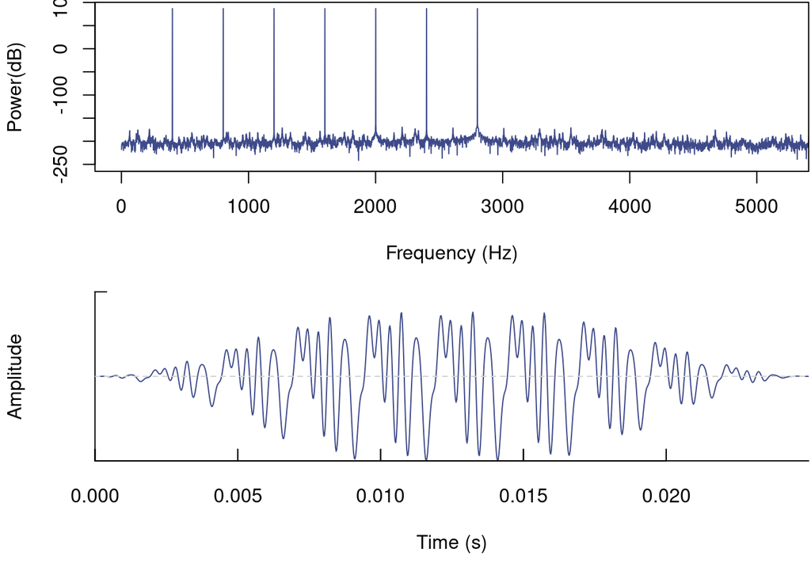

```r
ms <- make_schroeder(n.components = 7, samp.rate = 44100, f0 = 400,
    dur = 25, save.wave = FALSE, plot = TRUE, scalar = 1, color = viridis(10)[3],
    random.start = FALSE)
```

Negative

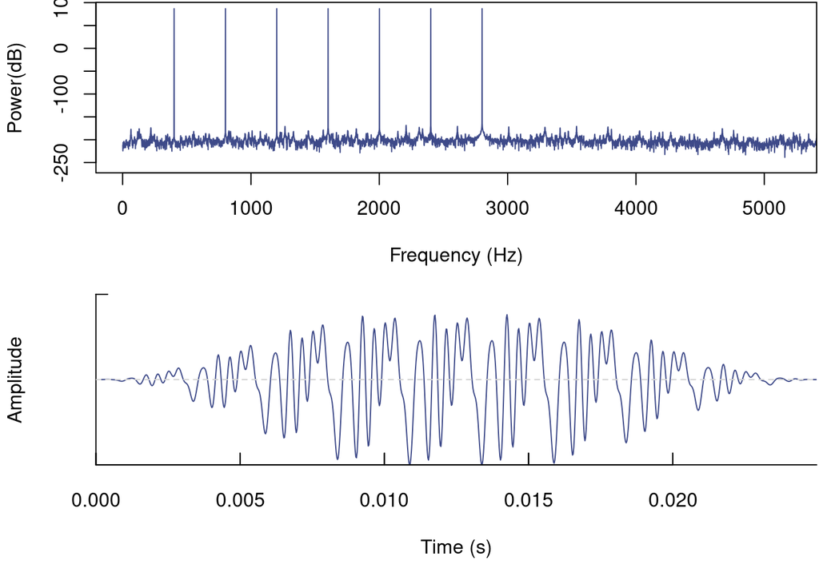

```r
ms <- make_schroeder(n.components = 7, samp.rate = 44100, f0 = 400,
    dur = 25, save.wave = FALSE, plot = TRUE, scalar = -1, color = viridis(10)[3])
```

### 3.1.2 Schroeder with 10 components

Positive

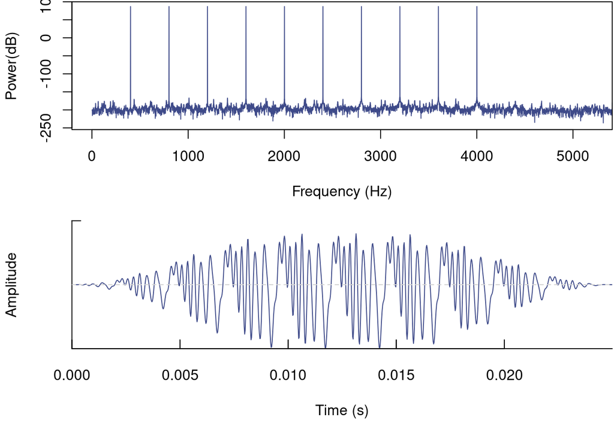

```r
ms <- make_schroeder(n.components = 10, samp.rate = 44100, f0 = 400,
    dur = 25, save.wave = FALSE, plot = TRUE, scalar = 1, color = viridis(10)[3])
```

Negative

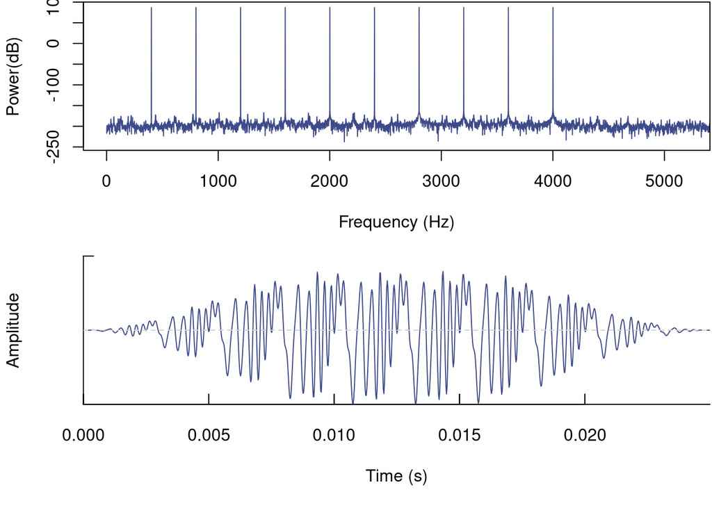

```r
ms <- make_schroeder(n.components = 10, samp.rate = 44100, f0 = 400,
    dur = 25, save.wave = FALSE, plot = TRUE, scalar = -1, color = viridis(10)[3])
```

Randomly starting at any point

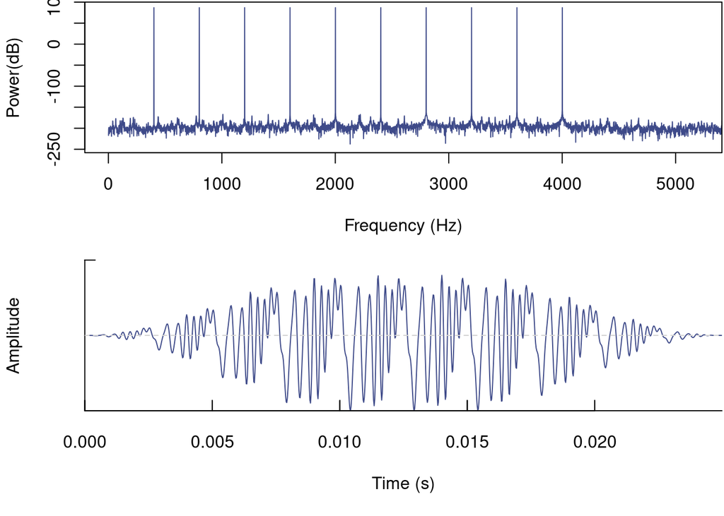

```r
ms <- make_schroeder(n.components = 10, samp.rate = 44100, f0 = 400,
    dur = 25, save.wave = FALSE, plot = TRUE, scalar = -1, color = viridis(10)[3],
    random.start = TRUE)
```

Make example video (or gif):

```r
ani.options(ani.res = 200, ani.width = 1700, ani.height = 1000, ani.type = "png")

## make sure ImageMagick has been installed in your system gifs
## <- function(lng_dat, type = 'gif'){

# anni_fun <- if(type == 'gif') saveGIF else saveVideo


saveGIF(expr = {

    for (i in 1:13) {
        par(mfcol = c(2, 2), mar = c(5, 5, 3, 2) + 0.1)

        ms <- make_schroeder(n.components = i, samp.rate = 44100,
            f0 = 400, dur = 25, save.wave = FALSE, plot = TRUE, scalar = 1,
            color = viridis(10)[3], random.start = FALSE, par = FALSE,
            main = paste0("Positive, ", i, " components"), cex.main = 2,
            cex.lab = 2, cex.oscillo = 2)

        ms <- make_schroeder(n.components = i, samp.rate = 44100,
            f0 = 400, dur = 25, save.wave = FALSE, plot = TRUE, scalar = -1,
            color = viridis(10)[8], random.start = FALSE, par = FALSE,
            main = paste0("Negative, ", i, " components"), cex.main = 2,
            cex.lab = 2, cex.oscillo = 2)

    }


}, video.name = file.path("./output/movies", "schroeders_by_sign_and_harmonics2"),
    interval = 1)
# }, movie.name = paste0(z, '.', type), interval = 0.05) }
```

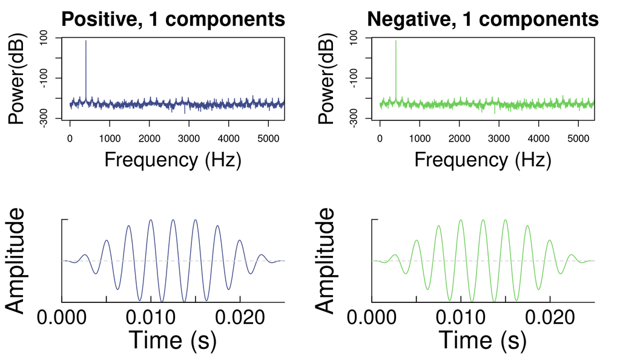

schroeders_by_sign_and_harmonics

## 3.2 Make schroeders

Full factorial design of the following features:

- Components: from 5 to 25 (21 values)
- Fundamental frequency: from 200 to 800 (7 values)
- Phase: 1 and -1
- 294 schroeders

Create schroeders as individual sound files:

- Fixed start

```r
shr_tab <- expand.grid(type = c(-1, 1), components = seq(5, 25, 1),
    f0 = seq(200, 800, 100))

nrow(shr_tab)


shr_tab$name <- paste0(f_pad_zero(x = 1:nrow(shr_tab), width = 3),
    "_f0-", shr_tab$f0, "_ncomp-", shr_tab$components, "_", ifelse(shr_tab$type ==
        1, "pos", "neg"), ".wav")

out <- warbleR:::pblapply_wrblr_int(seq_len(nrow(shr_tab)), function(x) {
    make_schroeder(n.components = shr_tab$components[x], samp.rate = 44100,
        f0 = shr_tab$f0[x], dur = 1000, save.wave = TRUE, plot = FALSE,
        scalar = shr_tab$type[x], color = "red", path = "./data/processed/schroeders",
        file.name = shr_tab$name[x])
})
```

- Random start

```r
shr_tab <- expand.grid(type = c(-1, 1), components = seq(5, 25, 1),
    f0 = seq(200, 800, 100))

nrow(shr_tab)


shr_tab$name <- paste0(f_pad_zero(x = 1:nrow(shr_tab), width = 3),
    "_f0-", shr_tab$f0, "_ncomp-", shr_tab$components, "_", ifelse(shr_tab$type ==
        1, "pos", "neg"), ".wav")

out <- warbleR:::pblapply_wrblr_int(seq_len(nrow(shr_tab)), function(x) {
    make_schroeder(n.components = shr_tab$components[x], samp.rate = 44100,
        f0 = shr_tab$f0[x], dur = 1000, save.wave = TRUE, plot = FALSE,
        scalar = shr_tab$type[x], color = "red", path = "./data/processed/random_start_schroeders",
        file.name = shr_tab$name[x], random.start = TRUE)
})
```

Put Schroeders into a single sound file

```r
# fix start
est_schr <- warbleR::selection_table(whole.recs = TRUE, path = "./data/processed/schroeders",
    extended = TRUE, confirm.extended = FALSE)

est_schr$bottom.freq <- (as.numeric(gsub("f0-", "", (sapply(strsplit(est_schr$sound.files,
    split = "_"), "[[", 2)))) - 50)/1000

est_schr$top.freq <- freq_range(X = est_schr, threshold = 2, fsmooth = 0.8,
    parallel = 13)$top.freq

est_schr$f0 <- gsub("f0-", "", sapply(strsplit(est_schr$sound.files,
    split = "_"), "[[", 2))

est_schr$label <- gsub("os.wav_1|eg.wav_1", "", sapply(strsplit(est_schr$sound.files,
    split = "ncomp-"), "[[", 2))

saveRDS(est_schr, "./data/processed/extended_selection_table_schroeders.RDS")

master <- master_sound_file(X = est_schr, file.name = "schroeder_master",
    dest.path = "./data/processed/", gap.duration = 0.8, cex = 14)

write.csv(master, "./data/processed/master_annotations_schroeders.csv",
    row.names = FALSE)

master$f0 <- c("start_marker", paste("f0", est_schr$f0), "")


master$label <- c("marker", est_schr$label, "marker")

Rraven::exp_raven(master, path = "./data/processed/", sound.file.path = "./data/processed/")

warbleR::full_spectrograms(master, path = "./data/processed/", sxrow = duration(readWave("./data/processed/schroeder_master.wav"))/12,
    rows = 12, horizontal = TRUE, dest.path = "./data/processed/spectrograms",
    collevels = seq(-150, 0, 5), labels = "label", song = "f0", wl = 2000)


# random start
est_schr <- warbleR::selection_table(whole.recs = TRUE, path = "./data/processed/random_start_schroeders",
    extended = TRUE, confirm.extended = FALSE)

est_schr$bottom.freq <- (as.numeric(gsub("f0-", "", (sapply(strsplit(est_schr$sound.files,
    split = "_"), "[[", 2)))) - 50)/1000

est_schr$top.freq <- freq_range(X = est_schr, threshold = 2, fsmooth = 0.8,
    parallel = 13)$top.freq

est_schr$f0 <- gsub("f0-", "", sapply(strsplit(est_schr$sound.files,
    split = "_"), "[[", 2))

est_schr$label <- gsub("os.wav_1|eg.wav_1", "", sapply(strsplit(est_schr$sound.files,
    split = "ncomp-"), "[[", 2))

saveRDS(est_schr, "./data/processed/extended_selection_table_random_start_schroeders.RDS")

master <- master_sound_file(X = est_schr, file.name = "random_start_schroeder_master",
    dest.path = "./data/processed/", gap.duration = 0.8, cex = 14)

write.csv(master, "./data/processed/master_annotations_random_start_schroeders.csv",
    row.names = FALSE)

master$f0 <- c("start_marker", paste("f0", est_schr$f0), "")


master$label <- c("marker", est_schr$label, "marker")

Rraven::exp_raven(master, file.name = "random_start_schroeders", path = "./data/processed/",
    sound.file.path = "./data/processed/")
```

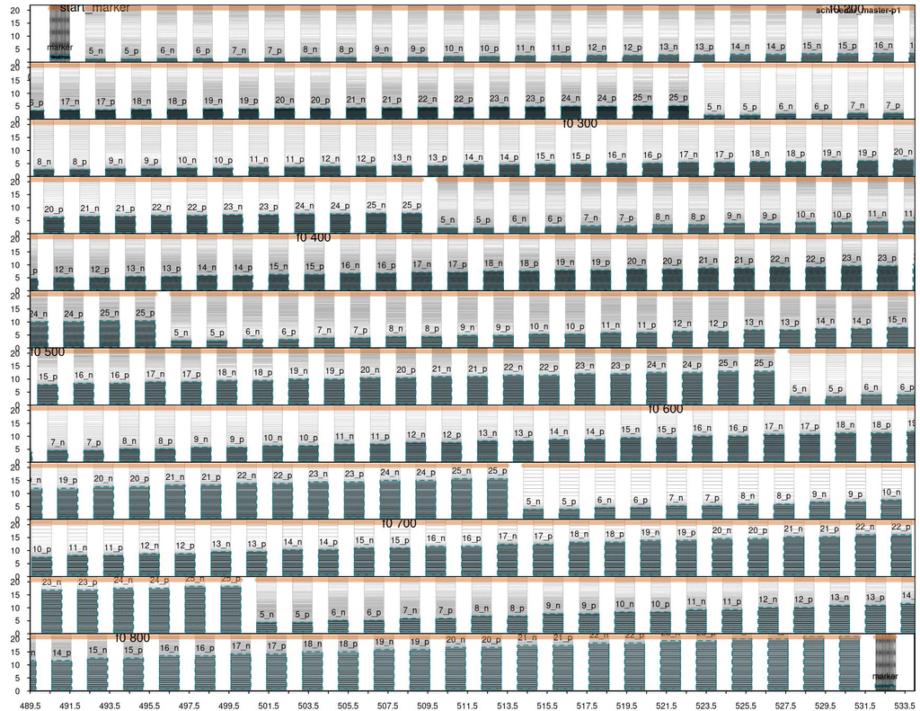

master sound file

# 4 Detecting periodicity

- Create a function that returns each detected segment in a list
- Two methods:
  - Empirical Mode Decomposition (EMD)
  - Time Autocorrelation (ac)
- The function can plot the mean period +/- standard deviation

```r
est_schr <- readRDS("./data/processed/extended_selection_table_schroeders.RDS")

source("~/Dropbox/Projects/acoustic_fine_features_zebra_finch/scripts/mean_segment.R")
```

```r
exp_est(est_schr, path = "./data/raw/extended_selection_table_schroeders_clips",
    file.name = "annotations")

est_schr <- resample_est(est_schr, bit.depth = 32)

# add silence
for (i in seq_len(nrow(est_schr))) {
    wv <- read_sound_file(est_schr, index = i)
    wv <- normalize(wv, unit = "32")

    # make it a 200 ms cut
    wv <- cutw(wave = wv, from = 0, to = 0.1, output = "Wave")
    # sil <- runif(min = min(wv@left) / 7, max = max(wv@left) /
    # 7, n = wv@samp.rate / 10) wv@left <- c(sil, wv@left, sil)
    # wv <- addsilw(wave = wv, at = 'end', d = 0.1, f = 44100,
    # output = 'Wave', ) wv <- addsilw(wave = wv, at = 'start',
    # d = 0.1, f = 44100, output = 'Wave')
    spectro(wv)

    filename <- file.path("./data/raw/extended_selection_table_schroeders_clips/100ms",
        gsub("_1$", "", est_schr$sound.files[i]))

    writeWave(object = wv, filename = filename, extensible = FALSE)
}

# fix_wavs(path =
# './data/raw/extended_selection_table_schroeders_clips/200ms')
```

## 4.1 Test function

mean period +/- standard deviation using autocorrelation

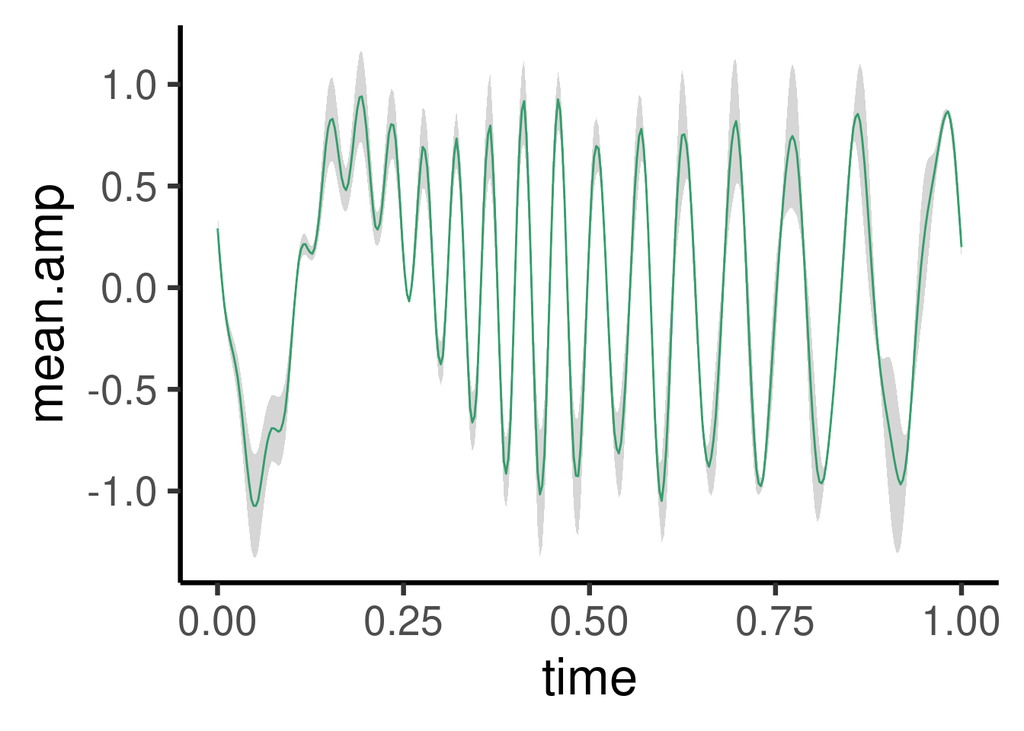

```r
est_schr <- readRDS("./data/processed/extended_selection_table_random_start_schroeders.RDS")

wave <- read_wave(est_schr, index = 40)

ms <- mean_segment(wave, thinning = 1, col = wave_col, mean = FALSE,
    plot = TRUE)
```

## 4.2 Get mean schroeder cycles

### 4.2.1 EMD method

```r
est_schr <- readRDS("./data/processed/extended_selection_table_random_start_schroeders.RDS")

mean_schroeders <- warbleR:::pblapply_wrblr_int(cl = 20, seq_len(nrow(est_schr)),
    function(x) {
        wave <- read_wave(est_schr, index = x)
        seg <- try_na(mean_segment(wave, plot = FALSE, mean = FALSE,
            type = "EMD"))

        return(seg)
    })

names(mean_schroeders) <- paste(est_schr$f0, est_schr$label, sep = "-")

saveRDS(mean_schroeders, "./data/processed/mean_random_start_schroeders_emd.RDS")
```

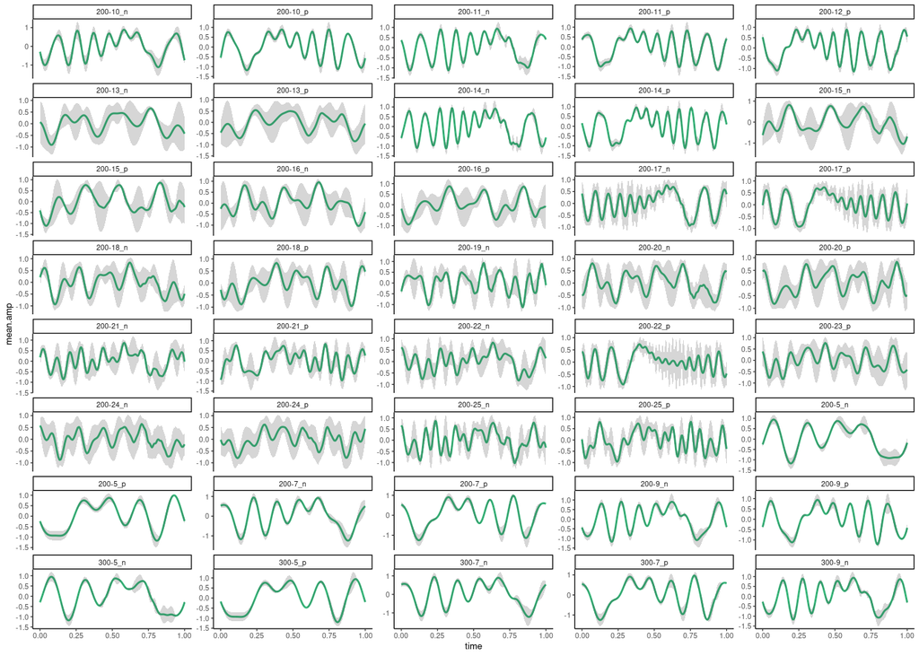

```r
mean_schroeders <- readRDS("./data/processed/mean_random_start_schroeders_emd.RDS")

mean_schroeders <- mean_schroeders[!sapply(mean_schroeders, function(x) is.na(x[[1]][1]))]

mean_schroeders_list <- lapply(seq_len(length(mean_schroeders)), function(x) {
    data.frame(schroeder = names(mean_schroeders)[x], time = seq(0,
        1, length.out = nrow(mean_schroeders[[x]])), mean.amp = rowMeans(mean_schroeders[[x]]),
        sd.amp = apply(mean_schroeders[[x]], 1, sd))
})

mean_schroeders_df <- do.call(rbind, mean_schroeders_list)

ggplot(data = mean_schroeders_df[mean_schroeders_df$schroeder %in%
    unique(mean_schroeders_df$schroeder)[1:40], ], mapping = aes(x = time,
    y = mean.amp)) + geom_line(color = wave_col) + geom_ribbon(aes(ymin = mean.amp -
    sd.amp, ymax = mean.amp + sd.amp), alpha = 0.2) + theme_classic(base_size = 5) +
    facet_wrap("~ schroeder", ncol = 5, scales = "free_y")
```

### 4.2.2 Autocorrelation method

```r
est_schr <- readRDS("./data/processed/extended_selection_table_random_start_schroeders.RDS")

mean_schroeders <- warbleR:::pblapply_wrblr_int(cl = 20, seq_len(nrow(est_schr)),
    function(x) {
        wave <- read_wave(est_schr, index = x)
        seg <- try_na(mean_segment(wave, plot = FALSE, mean = FALSE,
            type = "ac", thinning = 0.8))

        return(seg)
    })

names(mean_schroeders) <- paste(est_schr$f0, est_schr$label, sep = "-")

saveRDS(mean_schroeders, "./data/processed/mean_random_start_schroeders_ac.RDS")
```

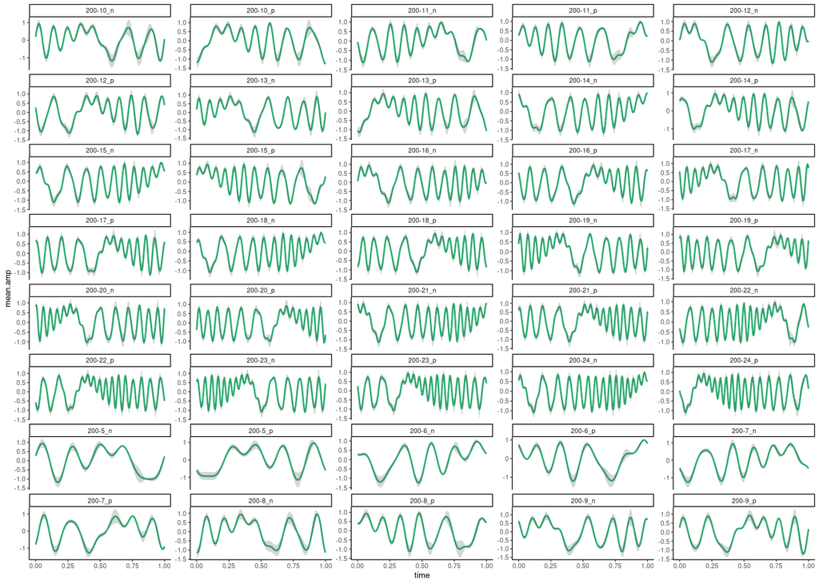

```r
mean_schroeders <- readRDS("./data/processed/mean_random_start_schroeders_ac.RDS")

mean_schroeders <- mean_schroeders[!sapply(mean_schroeders, function(x) is.na(x[[1]][1]))]

mean_schroeders_list <- lapply(seq_len(length(mean_schroeders)), function(x) {
    data.frame(schroeder = names(mean_schroeders)[x], time = seq(0,
        1, length.out = nrow(mean_schroeders[[x]])), mean.amp = rowMeans(mean_schroeders[[x]]),
        sd.amp = apply(mean_schroeders[[x]], 1, sd))
})

mean_schroeders_df <- do.call(rbind, mean_schroeders_list)

ggplot(data = mean_schroeders_df[mean_schroeders_df$schroeder %in%
    unique(mean_schroeders_df$schroeder)[1:40], ], mapping = aes(x = time,
    y = mean.amp)) + geom_line(color = wave_col) + geom_ribbon(aes(ymin = mean.amp -
    sd.amp, ymax = mean.amp + sd.amp), alpha = 0.2) + theme_classic(base_size = 5) +
    facet_wrap("~ schroeder", ncol = 5, scales = "free_y")
```

# 5 Measuring schroeder dissimilarity

## 5.1 Dynamic-time warping pairwise distance

- Both Schroeders have the same length
- One is duplicated and the other one is slide across the duplicated one
- The minimum DTW distance is kept as a dissimilarity measure

```r
mean_schroeders <- readRDS("./data/processed/mean_random_start_schroeders_ac.RDS")

nms <- names(mean_schroeders)
# nms <- grep(pattern = '200|400|600|800', nms, value = TRUE)

cmbs <- t(combn(nms, 2))


min_dist_l <- pbapply::pbsapply(cl = 22, 1:nrow(cmbs), function(x) {
    s1 <- rowMeans(mean_schroeders[[cmbs[x, 1]]])
    s2 <- rowMeans(mean_schroeders[[cmbs[x, 2]]])

    # make same length if (length(s1) != length(s2))
    s1 <- approx(s1, n = 100)$y
    s2 <- approx(s2, n = 100)$y

    # duplicate 1
    s1 <- rep(s1, 2)

    # run dtw over longer vector
    dists <- vapply(seq_len(length(s1) - length(s2)), function(x) {
        segment <- s1[x:min(c(x + length(s2) - 1), length(s1))]

        dtw_dist <- warbleR::try_na(dtw::dtwDist(mx = rbind(s2, segment)))
        return(dtw_dist[1, 2])
    }, FUN.VALUE = numeric(1))

    return(data.frame(schr1 = cmbs[x, 1], schdr2 = cmbs[x, 2], min(dists)))
})

min_dists <- do.call(rbind, min_dist_l)

min_dists <- as.data.frame(matrix(min_dists[, 1], ncol = 3, byrow = TRUE))

names(min_dists) <- c("schr1", "schr2", "dist")

min_dists$dist <- as.numeric(min_dists$dist)

saveRDS(min_dists, "./data/processed/dtw_distance_ac_segments_random_start.RDS")
```

# 6 Compare dissimilarity between schroeders using different methods

We try 11 methods for measuring acoustic structure:

- Dynamic time warping (DTW) distances from schroeder waveform
- Raven’s spectrographic features
- warbleR’s spectrographic features
- warbleR’s MFCC features
- warbleR’s cross-correlation of fourier spectrograms
- Raven’s cross-correlation of fourier spectrograms
- Raven’s waveform correlation
- warbleR’s cross-correlation of mel-frequency spectrograms
- DTW on warbleR’s dominant frequency contours
- DTW on Raven’s peak frequency contours
- Sound Analysis Pro similarity

Statistical modeling:

- [Multiple Regression on distance Matrices](https://search.r-project.org/CRAN/refmans/ecodist/html/MRM.html)
- Model:
  $$\begin{align*}
  Dissimilarity &\sim frequency + components + phase
  \end{align*}$$
- Response values scaled to make effect sizes comparable across models
- Predictors were coded as pairwise binary matrices in which 0 means that calls in a dyad belong to the same level and 1 means calls belong to different levels

## 6.1 Waveform DTW

```r
min_dists <- readRDS("./data/processed/dtw_distance_ac_segments_random_start.RDS")

min_dists$dist <- scale(min_dists$dist)

dist_tri <- PhenotypeSpace::rectangular_to_triangular(min_dists)

freq_bi_tri <- as.dist(binary_triangular_matrix(group = sapply(strsplit(rownames(dist_tri),
    "-"), "[[", 1)))

comp_bi_tri <- as.dist(binary_triangular_matrix(group = gsub("_n|_p",
    "", sapply(strsplit(rownames(dist_tri), "-"), "[[", 2))))

sign_bi_tri <- as.dist(binary_triangular_matrix(group = sapply(strsplit(rownames(dist_tri),
    "_"), "[[", 2)))

rect_var <- cbind(as.dist(dist_tri), freq_bi_tri, comp_bi_tri, sign_bi_tri)

colnames(rect_var) <- c("dtw_dist", "frequency", "components", "sign")

dtw_wv_mod <- MRM2(formula = dtw_dist ~ frequency + components + sign,
    nperm = 10000, mat = rect_var)

saveRDS(dtw_wv_mod, "./data/processed/matrix_correlation_dtw_distance_random_start.RDS")
```

```r
(dtw_wv_mod <- readRDS("./data/processed/matrix_correlation_dtw_distance_random_start.RDS"))
```

[output not shown]

## 6.2 Raven’s spectrographic features

```r
rav_dat <- imp_raven(path = "./data/processed", files = "random_start_schroeder_master_raven_measurements.txt",
    warbler.format = TRUE, all.data = TRUE)

rav_dat <- rav_dat[grep(pattern = "marker", rav_dat$f0, invert = TRUE),
    ]

rav_dat <- rav_dat[, grep("contour|PFC Slope", ignore.case = TRUE,
    x = names(rav_dat), invert = TRUE)]

pca <- prcomp(x = rav_dat[, names(rav_dat) %in% c("Agg Entropy (bits)",
    "Avg Entropy (bits)", "Avg Power Density (dB FS/Hz)", "BW 50% (Hz)",
    "BW 90% (Hz)", "Center Freq (Hz)", "Center Time Rel.", "Delta Freq (Hz)",
    "Dur 50% (s)", "Dur 90% (s)", "Energy (dB FS)", "Freq 25% (Hz)",
    "Freq 5% (Hz)", "Freq 75% (Hz)", "Freq 95% (Hz)", "Inband Power (dB FS)",
    "Max Entropy (bits)", "Max Freq (Hz)", "Min Entropy (bits)", "Peak Freq (Hz)",
    "PFC Avg Slope (Hz/ms)", "PFC Max Freq (Hz)", "PFC Max Slope (Hz/ms)",
    "PFC Min Freq (Hz)", "PFC Min Slope (Hz/ms)", "PFC Num Inf Pts",
    "Peak Power Density (dB FS/Hz)", "Peak Time (s)", "Peak Time Relative",
    "Time 25% (s)", "Time 25% Rel.", "Time 5% (s)", "Time 5% Rel.",
    "Time 75% (s)", "Time 75% Rel.", "Time 95% (s)", "Time 95% Rel.")],
    scale. = TRUE)

rav_dat$pc1 <- pca$x[, 1]
rav_dat$pc2 <- pca$x[, 2]
rav_dat$comp <- sapply(strsplit(rav_dat$label, "_"), "[[", 1)
rav_dat$sign <- sapply(strsplit(rav_dat$label, "_"), "[[", 2)
rav_dat$label <- paste(rav_dat$f0, rav_dat$label, sep = "-")

dist_tri <- dist(rav_dat[, c("pc1", "pc2")])

freq_bi_tri <- as.dist(binary_triangular_matrix(group = rav_dat$f0))

comp_bi_tri <- as.dist(binary_triangular_matrix(group = rav_dat$comp))

sign_bi_tri <- as.dist(binary_triangular_matrix(group = rav_dat$sign))

rect_var <- cbind(as.dist(scale(as.matrix(dist_tri))), freq_bi_tri,
    comp_bi_tri, sign_bi_tri)

colnames(rect_var) <- c("rav_dist", "frequency", "components", "sign")


rav_mod <- MRM2(formula = rav_dist ~ frequency + components + sign,
    nperm = 10000, mat = rect_var)

saveRDS(rav_mod, "./data/processed/matrix_correlation_raven_measurements_distance_random_start.RDS")
```

```r
(rav_mod <- readRDS("./data/processed/matrix_correlation_raven_measurements_distance_random_start.RDS"))
```

```
$coef
               rav_dist   pval
Int        -1.308738783 0.0001
frequency   0.879062058 0.0001
components  0.655162497 0.0001
sign       -0.004605695 0.5591

$r.squared
        R2       pval
0.09958528 0.00010000

$F.test
        F    F.pval
1587.7273    0.0001
```

## 6.3 warbleR’s spectrographic features

```r
est_schr <- readRDS("./data/processed/extended_selection_table_random_start_schroeders.RDS")

wsp <- spectro_analysis(est_schr, harmonicity = TRUE, nharmonics = 5,
    parallel = 20)

# keep columns with no NAs
wsp <- wsp[complete.cases(wsp), ]

pca <- prcomp(x = wsp[, -c(1:3)])
wsp$pc1 <- pca$x[, 1]
wsp$pc2 <- pca$x[, 2]

wsp_tri <- dist(wsp[, c("pc1", "pc2")])

freq_bi_tri <- as.dist(binary_triangular_matrix(group = substr(sapply(strsplit(wsp$sound.files,
    "_"), "[[", 2), start = 4, 6)))

comp_bi_tri <- as.dist(binary_triangular_matrix(group = substr(sapply(strsplit(wsp$sound.files,
    "_"), "[[", 3), start = 7, 8)))

sign_bi_tri <- as.dist(binary_triangular_matrix(group = ifelse(grepl("pos",
    wsp$sound.files), "pos", "neg")))

rect_var <- cbind(as.dist(scale(as.matrix(wsp_tri))), freq_bi_tri,
    comp_bi_tri, sign_bi_tri)

colnames(rect_var) <- c("wrbl_sp", "frequency", "components", "sign")

wrbl_mod <- MRM2(formula = wrbl_sp ~ frequency + components + sign,
    nperm = 10000, mat = rect_var)

saveRDS(wrbl_mod, "./data/processed/matrix_correlation_warbler_measurements_distance_random_start.RDS")
```

```r
(wrbl_mod <- readRDS("./data/processed/matrix_correlation_warbler_measurements_distance_random_start.RDS"))
```

```
$coef
                wrbl_sp   pval
Int        -1.310541864 0.0001
frequency   1.536291158 0.0001
components  0.104840203 0.0002
sign       -0.005210514 0.5868

$r.squared
       R2      pval
0.3557964 0.0001000

$F.test
        F    F.pval
4116.8767    0.0001
```

## 6.4 warbleR’s MFCC features

```r
est_schr <- readRDS("./data/processed/extended_selection_table_random_start_schroeders.RDS")

wsp <- mfcc_stats(est_schr)

# keep columns with no NAs
wsp <- wsp[complete.cases(wsp), ]

pca <- prcomp(x = wsp[, -c(1:3)])
wsp$pc1 <- pca$x[, 1]
wsp$pc2 <- pca$x[, 2]

wsp_tri <- dist(wsp[, c("pc1", "pc2")])

freq_bi_tri <- as.dist(binary_triangular_matrix(group = substr(sapply(strsplit(wsp$sound.files,
    "_"), "[[", 2), start = 4, 6)))

comp_bi_tri <- as.dist(binary_triangular_matrix(group = substr(sapply(strsplit(wsp$sound.files,
    "_"), "[[", 3), start = 7, 8)))

sign_bi_tri <- as.dist(binary_triangular_matrix(group = ifelse(grepl("pos",
    wsp$sound.files), "pos", "neg")))

rect_var <- cbind(as.dist(scale(as.matrix(wsp_tri))), freq_bi_tri,
    comp_bi_tri, sign_bi_tri)

colnames(rect_var) <- c("wrbl_sp", "frequency", "components", "sign")

mfcc_wrbl_mod <- MRM2(formula = wrbl_sp ~ frequency + components +
    sign, nperm = 10000, mat = rect_var)

saveRDS(mfcc_wrbl_mod, "./data/processed/mfcc_warbler_distance_random_start.RDS")
```

```r
(mfcc_wrbl_mod <- readRDS("./data/processed/mfcc_warbler_distance_random_start.RDS"))
```

```
$coef
                wrbl_sp   pval
Int        -0.982621684 0.0001
frequency   1.084976216 0.0001
components  0.077849463 0.0007
sign       -0.003561353 0.6436

$r.squared
       R2      pval
0.1378832 0.0001000

$F.test
        F    F.pval
2295.9832    0.0001
```

## 6.5 warbleR’s fourier cross-correlation

```r
est_schr <- readRDS("./data/processed/extended_selection_table_random_start_schroeders.RDS")

xc <- cross_correlation(est_schr)

saveRDS(xc, "./data/processed/fourier_cross_correlation_random_start_schroeder.RDS")
```

```r
xc <- readRDS("./data/processed/fourier_cross_correlation_random_start_schroeder.RDS")

freq_bi_tri <- as.dist(binary_triangular_matrix(group = substr(sapply(strsplit(rownames(xc),
    "_"), "[[", 2), start = 4, 6)))

comp_bi_tri <- as.dist(binary_triangular_matrix(group = substr(sapply(strsplit(rownames(xc),
    "_"), "[[", 3), start = 7, 8)))

sign_bi_tri <- as.dist(binary_triangular_matrix(group = ifelse(grepl("pos",
    rownames(xc)), "pos", "neg")))

rect_var <- cbind(as.dist(scale(1 - xc)), freq_bi_tri, comp_bi_tri,
    sign_bi_tri)

colnames(rect_var) <- c("fourier_xc", "frequency", "components", "sign")

xc_mod <- MRM2(formula = fourier_xc ~ frequency + components + sign,
    nperm = 10000, mat = rect_var)

saveRDS(xc_mod, "./data/processed/matrix_correlation_fourier_cross_correlation_random_start.RDS")
```

```r
(xc_mod <- readRDS("./data/processed/matrix_correlation_fourier_cross_correlation_random_start.RDS"))
```

```
$coef
            fourier_xc   pval
Int        -1.78485496 0.0001
frequency   1.98172165 0.0001
components  0.14076790 0.0001
sign       -0.02157745 0.0081

$r.squared
       R2      pval
0.5070224 0.0001000

$F.test
         F     F.pval
14764.6553     0.0001
```

## 6.6 Raven’s fourier cross-correlation

```r
xc_rav <- Rraven::imp_corr_mat(file = "random_start_schroeders_raven_fourier_cross_correlation.txt",
    path = "./data/processed")[[1]]

freq_bi_tri <- as.dist(binary_triangular_matrix(group = substr(sapply(strsplit(rownames(xc_rav),
    "_"), "[[", 2), start = 4, 6)))

comp_bi_tri <- as.dist(binary_triangular_matrix(group = substr(sapply(strsplit(rownames(xc_rav),
    "_"), "[[", 3), start = 7, 8)))

sign_bi_tri <- as.dist(binary_triangular_matrix(group = ifelse(grepl("pos",
    rownames(xc_rav)), "pos", "neg")))

rect_var <- cbind(as.dist(scale(1 - xc_rav)), freq_bi_tri, comp_bi_tri,
    sign_bi_tri)

colnames(rect_var) <- c("fourier_xc_rav", "frequency", "components",
    "sign")

xc_rav_mod <- MRM2(formula = fourier_xc_rav ~ frequency + components +
    sign, nperm = 10000, mat = rect_var)

saveRDS(xc_rav_mod, "./data/processed/matrix_correlation_raven_fourier_cross_correlation_random_start.RDS")
```

```r
(xc_rav_mod <- readRDS("./data/processed/matrix_correlation_raven_fourier_cross_correlation_random_start.RDS"))
```

```
$coef
           fourier_xc_rav   pval
Int            -1.7370728 0.0001
frequency       1.7351569 0.0001
components      0.2531801 0.0001
sign            0.0246393 0.0072

$r.squared
       R2      pval
0.3757609 0.0001000

$F.test
        F    F.pval
8700.3890    0.0001
```

## 6.7 Raven’s waveform correlation

```r
wav_cr_rav <- Rraven::imp_corr_mat(file = "random_start_schroeders_raven_waveform_correlation.txt",
    path = "./data/processed")[[1]]

freq_bi_tri <- as.dist(binary_triangular_matrix(group = substr(sapply(strsplit(rownames(wav_cr_rav),
    "_"), "[[", 2), start = 4, 6)))

comp_bi_tri <- as.dist(binary_triangular_matrix(group = substr(sapply(strsplit(rownames(wav_cr_rav),
    "_"), "[[", 3), start = 7, 8)))

sign_bi_tri <- as.dist(binary_triangular_matrix(group = ifelse(grepl("pos",
    rownames(wav_cr_rav)), "pos", "neg")))

rect_var <- cbind(as.dist(scale(1 - wav_cr_rav)), freq_bi_tri, comp_bi_tri,
    sign_bi_tri)

colnames(rect_var) <- c("fourier_wav_cr_rav", "frequency", "components",
    "sign")

wav_cr_rav_mod <- MRM2(formula = fourier_wav_cr_rav ~ frequency +
    components + sign, nperm = 10000, mat = rect_var)

saveRDS(wav_cr_rav_mod, "./data/processed/matrix_correlation_raven_waveform_correlation_random_start.RDS")
```

```r
(wav_cr_rav_mod <- readRDS("./data/processed/matrix_correlation_raven_waveform_correlation_random_start.RDS"))
```

```
$coef
           fourier_wav_cr_rav   pval
Int               -1.70508855 0.0001
frequency          1.88607629 0.0001
components         0.04258164 0.0061
sign               0.11819114 0.0001

$r.squared
       R2      pval
0.4953648 0.0001000

$F.test
         F     F.pval
14188.1430     0.0001
```

## 6.8 warbleR’s mel-frequency cross-correlation

```r
est_schr <- readRDS("./data/processed/extended_selection_table_random_start_schroeders.RDS")

xc <- cross_correlation(est_schr, type = "mfcc")

saveRDS(xc, "./data/processed/mel_frequency_cross_correlation_schroeder_random_start.RDS")
```

```r
xc <- readRDS("./data/processed/mel_frequency_cross_correlation_schroeder_random_start.RDS")

freq_bi_tri <- as.dist(binary_triangular_matrix(group = substr(sapply(strsplit(rownames(xc),
    "_"), "[[", 2), start = 4, 6)))

comp_bi_tri <- as.dist(binary_triangular_matrix(group = substr(sapply(strsplit(rownames(xc),
    "_"), "[[", 3), start = 7, 8)))

sign_bi_tri <- as.dist(binary_triangular_matrix(group = ifelse(grepl("pos",
    rownames(xc)), "pos", "neg")))

rect_var <- cbind(as.dist(scale(1 - xc)), freq_bi_tri, comp_bi_tri,
    sign_bi_tri)


colnames(rect_var) <- c("mel_xc", "frequency", "components", "sign")


mxc_mod <- MRM2(formula = mel_xc ~ frequency + components + sign,
    nperm = 10000, mat = rect_var)

saveRDS(mxc_mod, "./data/processed/matrix_correlation_mel_cross_correlation_random_start.RDS")
```

```r
(mxc_mod <- readRDS("./data/processed/matrix_correlation_mel_cross_correlation_random_start.RDS"))
```

```
$coef
                  mel_xc   pval
Int        -1.2613675324 0.0001
frequency   1.2552094577 0.0001
components  0.2486046157 0.0001
sign        0.0008366943 0.9119

$r.squared
       R2      pval
0.1794016 0.0001000

$F.test
        F    F.pval
3138.4764    0.0001
```

## 6.9 DTW on warbleR’s dominant frequency contours

```r
source("~/Dropbox/R_package_testing/warbleR/R/freq_DTW.R")
source("~/Dropbox/R_package_testing/warbleR/R/internal_functions.R")

est_schr <- readRDS("./data/processed/extended_selection_table_random_start_schroeders.RDS")

dtw_dists <- freq_DTW(est_schr, type = "dominant", img = FALSE)

saveRDS(dtw_dists, "./data/processed/dtw_distance_dominant_frequency_schroeder_random_start.RDS")
```

```r
dtw_dists <- readRDS("./data/processed/dtw_distance_dominant_frequency_schroeder_random_start.RDS")

freq_bi_tri <- as.dist(binary_triangular_matrix(group = substr(sapply(strsplit(rownames(dtw_dists),
    "_"), "[[", 2), start = 4, 6)))

comp_bi_tri <- as.dist(binary_triangular_matrix(group = substr(sapply(strsplit(rownames(dtw_dists),
    "_"), "[[", 3), start = 7, 8)))

sign_bi_tri <- as.dist(binary_triangular_matrix(group = ifelse(grepl("pos",
    rownames(dtw_dists)), "pos", "neg")))

rect_var <- cbind(as.dist(scale(dtw_dists)), freq_bi_tri, comp_bi_tri,
    sign_bi_tri)

colnames(rect_var) <- c("dtw_dists", "frequency", "components", "sign")

dtw_dom_mod <- MRM2(formula = dtw_dists ~ frequency + components +
    sign, nperm = 10000, mat = rect_var)

saveRDS(dtw_dom_mod, "./data/processed/matrix_correlation_dtw_distances_dominant_frequency_contours_random_start.RDS")
```

```r
(dtw_dom_mod <- readRDS("./data/processed/matrix_correlation_dtw_distances_dominant_frequency_contours_random_start.RDS"))
```

```
$coef
              dtw_dists   pval
Int        -0.456171403 0.0001
frequency   0.526558411 0.0001
components  0.157208372 0.0001
sign       -0.004413661 0.5422

$r.squared
        R2       pval
0.02564736 0.00010000

$F.test
       F   F.pval
377.8765   0.0001
```

## 6.10 DTW on Raven’s peak frequency contours

```r
source("~/Dropbox/R_package_testing/warbleR/R/freq_DTW.R")
source("~/Dropbox/R_package_testing/warbleR/R/internal_functions.R")

rav_dat <- imp_raven(path = "./data/processed", files = "random_start_schroeder_master_raven_measurements.txt",
    warbler.format = TRUE, all.data = TRUE)

rav_dat <- rav_dat[grep(pattern = "marker", rav_dat$f0, invert = TRUE),
    ]

# rav_dat <- rav_dat[, grep('contour|PFC Slope', ignore.case =
# TRUE, x = names(rav_dat), invert = TRUE)]

rav_freq_cntr <- extract_ts(rav_dat, ts.column = "Peak Freq Contour (Hz)",
    equal.length = TRUE)


est_schr <- readRDS("./data/processed/extended_selection_table_random_start_schroeders.RDS")

rav_dtw_dists <- freq_DTW(est_schr, ts.df = rav_freq_cntr, type = "dominant",
    img = FALSE)

rownames(rav_dtw_dists) <- rav_dat$orig.sound.file

saveRDS(rav_dtw_dists, "./data/processed/dtw_distance_raven_dominant_frequency_random_start_schroeder.RDS")
```

```r
rav_dtw_dists <- readRDS("./data/processed/dtw_distance_raven_dominant_frequency_random_start_schroeder.RDS")

freq_bi_tri <- as.dist(binary_triangular_matrix(group = substr(sapply(strsplit(rownames(rav_dtw_dists),
    "_"), "[[", 2), start = 4, 6)))

comp_bi_tri <- as.dist(binary_triangular_matrix(group = substr(sapply(strsplit(rownames(rav_dtw_dists),
    "_"), "[[", 3), start = 7, 8)))

sign_bi_tri <- as.dist(binary_triangular_matrix(group = ifelse(grepl("pos",
    rownames(rav_dtw_dists)), "pos", "neg")))

rect_var <- cbind(as.dist(scale(rav_dtw_dists)), freq_bi_tri, comp_bi_tri,
    sign_bi_tri)

colnames(rect_var) <- c("rav_dtw_dists", "frequency", "components",
    "sign")

source("~/Dropbox/Projects/geographic_call_variation_yellow-naped_amazon/scripts/MRM2.R")

dtw_rav_peak_mod <- MRM2(formula = rav_dtw_dists ~ frequency + components +
    sign, nperm = 10000, mat = rect_var)

saveRDS(dtw_rav_peak_mod, "./data/processed/matrix_correlation_dtw_distances_raven_dominant_frequency_contours_random_start.RDS")
```

```r
(dtw_rav_peak_mod <- readRDS("./data/processed/matrix_correlation_dtw_distances_raven_dominant_frequency_contours_random_start.RDS"))
```

```
$coef
           rav_dtw_dists   pval
Int        -0.8465155615 0.0001
frequency   1.1803304963 0.0001
components  0.0468889213 0.0323
sign        0.0009260393 0.9175

$r.squared
       R2      pval
0.1363664 0.0001000

$F.test
        F    F.pval
2266.7382    0.0001
```

## 6.11 SAP similarity

- SAP: sound analysis pro
- This analysis was done on 200 ms clips as longer clips did not run in SAP

```r
simil_sap <- readxl::read_xlsx("./data/raw/200ms_SAPsim.xlsx")

# fix weird similarities
simil_sap$`%Similarity`[simil_sap$Accuracy == -1] <- mean(simil_sap$`%Similarity`,
    na.rm = TRUE)

# number of pairwise comparisons posibles
clips <- unique(c(simil_sap$`Sound 1`, simil_sap$`Sound 2`))

ncol(poss_combs <- combn(clips, 2))

poss_combs <- t(poss_combs)

poss_dyad <- sapply(seq_len(nrow(poss_combs)), function(x) {
    paste(sort(c(poss_combs[x, 1], poss_combs[x, 2])), collapse = "|")
})


simil_sap$dyad <- sapply(seq_len(nrow(simil_sap)), function(x) {
    paste(sort(c(simil_sap$`Sound 1`[x], simil_sap$`Sound 2`[x])),
        collapse = "|")
})

# remove duplicated dyads
simil_sap <- simil_sap[!duplicated(simil_sap$dyad), ]

# remove self comparisons
simil_sap <- simil_sap[!simil_sap$`Sound 1` == simil_sap$`Sound 2`,
    ]

nrow(simil_sap)

# missing dyads
missing <- poss_dyad[!poss_dyad %in% simil_sap$dyad]

# split missing by |
missing <- unique(c(sapply(strsplit(missing, "|", fixed = TRUE), "[[",
    1), sapply(strsplit(missing, "|", fixed = TRUE), "[[", 2)))

# remove missing clips
simil_sap <- simil_sap[!(simil_sap$`Sound 1` %in% missing | simil_sap$`Sound 2` %in%
    missing), ]

# get symmetric triangular matrix
dist_sap <- rectangular_to_triangular(as.data.frame(simil_sap))

freq_bi_tri <- as.dist(binary_triangular_matrix(group = substr(sapply(strsplit(rownames(dist_sap),
    "_"), "[[", 2), start = 4, 6)))

comp_bi_tri <- as.dist(binary_triangular_matrix(group = substr(sapply(strsplit(rownames(dist_sap),
    "_"), "[[", 3), start = 7, 8)))

sign_bi_tri <- as.dist(binary_triangular_matrix(group = ifelse(grepl("pos",
    rownames(dist_sap)), "pos", "neg")))

rect_var <- cbind(as.dist(scale(1 - dist_sap)), freq_bi_tri, comp_bi_tri,
    sign_bi_tri)

colnames(rect_var) <- c("dist_sap", "frequency", "components", "sign")

rect_var[is.na(rect_var[, 1]), 1] <- mean(rect_var[, 1], na.rm = TRUE)

dist_sap_mod <- MRM2(formula = dist_sap ~ frequency + components +
    sign, nperm = 10000, mat = rect_var)

saveRDS(dist_sap_mod, "./data/processed/matrix_correlation_sound_analysis_pro_200_ms_clips.RDS")
```

```r
(dist_sap_mod <- readRDS("./data/processed/matrix_correlation_sound_analysis_pro_200_ms_clips.RDS"))
```

```
$coef
                dist_sap   pval
Int        -1.0474374027 0.0001
frequency   1.3171980171 0.0001
components  0.0285901529 0.1798
sign        0.0006323237 0.9344

$r.squared
      R2     pval
0.178686 0.000100

$F.test
        F    F.pval
3123.2347    0.0001

$n
[1] 294
```

## 6.12 SAP accuracy

- SAP: sound analysis pro
- This analysis was done on 200 ms clips as longer clips did not run in SAP

```r
simil_sap <- readxl::read_xlsx("./data/raw/200ms_SAPsim.xlsx")

# fix weird similarities
simil_sap$Accuracy[simil_sap$Accuracy == -1] <- mean(simil_sap$Accuracy[simil_sap$Accuracy !=
    -1], na.rm = TRUE)

# number of pairwise comparisons posibles
clips <- unique(c(simil_sap$`Sound 1`, simil_sap$`Sound 2`))

ncol(poss_combs <- combn(clips, 2))

poss_combs <- t(poss_combs)

poss_dyad <- sapply(seq_len(nrow(poss_combs)), function(x) {
    paste(sort(c(poss_combs[x, 1], poss_combs[x, 2])), collapse = "|")
})


simil_sap$dyad <- sapply(seq_len(nrow(simil_sap)), function(x) {
    paste(sort(c(simil_sap$`Sound 1`[x], simil_sap$`Sound 2`[x])),
        collapse = "|")
})

# remove duplicated dyads
simil_sap <- simil_sap[!duplicated(simil_sap$dyad), ]

# remove self comparisons
simil_sap <- simil_sap[!simil_sap$`Sound 1` == simil_sap$`Sound 2`,
    ]

nrow(simil_sap)

# missing dyads
missing <- poss_dyad[!poss_dyad %in% simil_sap$dyad]

# split missing by |
missing <- unique(c(sapply(strsplit(missing, "|", fixed = TRUE), "[[",
    1), sapply(strsplit(missing, "|", fixed = TRUE), "[[", 2)))

# remove missing clips
simil_sap <- simil_sap[!(simil_sap$`Sound 1` %in% missing | simil_sap$`Sound 2` %in%
    missing), ]

# get symmetric triangular matrix
dist_sap <- rectangular_to_triangular(as.data.frame(simil_sap[, c("Sound 1",
    "Sound 2", "Accuracy")]))

freq_bi_tri <- as.dist(binary_triangular_matrix(group = substr(sapply(strsplit(rownames(dist_sap),
    "_"), "[[", 2), start = 4, 6)))

comp_bi_tri <- as.dist(binary_triangular_matrix(group = substr(sapply(strsplit(rownames(dist_sap),
    "_"), "[[", 3), start = 7, 8)))

sign_bi_tri <- as.dist(binary_triangular_matrix(group = ifelse(grepl("pos",
    rownames(dist_sap)), "pos", "neg")))

rect_var <- cbind(as.dist(scale(1 - dist_sap)), freq_bi_tri, comp_bi_tri,
    sign_bi_tri)

colnames(rect_var) <- c("dist_sap", "frequency", "components", "sign")

rect_var[is.na(rect_var[, 1]), 1] <- mean(rect_var[, 1], na.rm = TRUE)

acc_sap_mod <- MRM2(formula = dist_sap ~ frequency + components +
    sign, nperm = 10000, mat = rect_var)

saveRDS(acc_sap_mod, "./data/processed/matrix_correlation_sound_analysis_pro_accuracy_200_ms_clips.RDS")
```

```r
(acc_sap_mod <- readRDS("./data/processed/matrix_correlation_sound_analysis_pro_accuracy_200_ms_clips.RDS"))
```

```
$coef
               dist_sap   pval
Int        -0.791591414 0.0001
frequency   0.801166273 0.0001
components  0.057881918 0.0028
sign        0.003937408 0.5814

$r.squared
       R2      pval
0.1033568 0.0001000

$F.test
        F    F.pval
1654.7898    0.0001

$n
[1] 294
```

## 6.13 SAP harmonic goodness

- SAP: sound analysis pro
- This analysis was done on 200 ms clips as longer clips did not run in SAP

```r
simil_sap <- readxl::read_xlsx("./data/raw/200ms_SAPsim.xlsx")


# number of pairwise comparisons posibles
clips <- unique(c(simil_sap$`Sound 1`, simil_sap$`Sound 2`))

ncol(poss_combs <- combn(clips, 2))

poss_combs <- t(poss_combs)

poss_dyad <- sapply(seq_len(nrow(poss_combs)), function(x) {
    paste(sort(c(poss_combs[x, 1], poss_combs[x, 2])), collapse = "|")
})


simil_sap$dyad <- sapply(seq_len(nrow(simil_sap)), function(x) {
    paste(sort(c(simil_sap$`Sound 1`[x], simil_sap$`Sound 2`[x])),
        collapse = "|")
})

# remove duplicated dyads
simil_sap <- simil_sap[!duplicated(simil_sap$dyad), ]

# remove self comparisons
simil_sap <- simil_sap[!simil_sap$`Sound 1` == simil_sap$`Sound 2`,
    ]

nrow(simil_sap)

# missing dyads
missing <- poss_dyad[!poss_dyad %in% simil_sap$dyad]

# split missing by |
missing <- unique(c(sapply(strsplit(missing, "|", fixed = TRUE), "[[",
    1), sapply(strsplit(missing, "|", fixed = TRUE), "[[", 2)))

# remove missing clips
simil_sap <- simil_sap[!(simil_sap$`Sound 1` %in% missing | simil_sap$`Sound 2` %in%
    missing), ]

# get symmetric triangular matrix
dist_sap <- rectangular_to_triangular(as.data.frame(simil_sap[, c("Sound 1",
    "Sound 2", "Goodness diff")]))

freq_bi_tri <- as.dist(binary_triangular_matrix(group = substr(sapply(strsplit(rownames(dist_sap),
    "_"), "[[", 2), start = 4, 6)))

comp_bi_tri <- as.dist(binary_triangular_matrix(group = substr(sapply(strsplit(rownames(dist_sap),
    "_"), "[[", 3), start = 7, 8)))

sign_bi_tri <- as.dist(binary_triangular_matrix(group = ifelse(grepl("pos",
    rownames(dist_sap)), "pos", "neg")))

rect_var <- cbind(as.dist(scale(1 - dist_sap)), freq_bi_tri, comp_bi_tri,
    sign_bi_tri)

colnames(rect_var) <- c("dist_sap", "frequency", "components", "sign")

rect_var[is.na(rect_var[, 1]), 1] <- mean(rect_var[, 1], na.rm = TRUE)

good_sap_mod <- MRM2(formula = dist_sap ~ frequency + components +
    sign, nperm = 10000, mat = rect_var)

saveRDS(good_sap_mod, "./data/processed/matrix_correlation_sound_analysis_pro_goodness_200_ms_clips.RDS")
```

```r
(good_sap_mod <- readRDS("./data/processed/matrix_correlation_sound_analysis_pro_goodness_200_ms_clips.RDS"))
```

```
$coef
               dist_sap   pval
Int         0.711874155 0.0001
frequency  -1.182727718 0.0001
components  0.009919279 0.5938
sign        0.000160463 0.9854

$r.squared
       R2      pval
0.1197922 0.0001000

$F.test
        F    F.pval
1953.7405    0.0001

$n
[1] 294
```

## 6.14 SAP pitch difference

- SAP: sound analysis pro
- This analysis was done on 200 ms clips as longer clips did not run in SAP

```r
simil_sap <- readxl::read_xlsx("./data/raw/200ms_SAPsim.xlsx")

# number of pairwise comparisons posibles
clips <- unique(c(simil_sap$`Sound 1`, simil_sap$`Sound 2`))

ncol(poss_combs <- combn(clips, 2))

poss_combs <- t(poss_combs)

poss_dyad <- sapply(seq_len(nrow(poss_combs)), function(x) {
    paste(sort(c(poss_combs[x, 1], poss_combs[x, 2])), collapse = "|")
})


simil_sap$dyad <- sapply(seq_len(nrow(simil_sap)), function(x) {
    paste(sort(c(simil_sap$`Sound 1`[x], simil_sap$`Sound 2`[x])),
        collapse = "|")
})

# remove duplicated dyads
simil_sap <- simil_sap[!duplicated(simil_sap$dyad), ]

# remove self comparisons
simil_sap <- simil_sap[!simil_sap$`Sound 1` == simil_sap$`Sound 2`,
    ]

nrow(simil_sap)

# missing dyads
missing <- poss_dyad[!poss_dyad %in% simil_sap$dyad]

# split missing by |
missing <- unique(c(sapply(strsplit(missing, "|", fixed = TRUE), "[[",
    1), sapply(strsplit(missing, "|", fixed = TRUE), "[[", 2)))

# remove missing clips
simil_sap <- simil_sap[!(simil_sap$`Sound 1` %in% missing | simil_sap$`Sound 2` %in%
    missing), ]

# get symmetric triangular matrix
dist_sap <- rectangular_to_triangular(as.data.frame(simil_sap[, c("Sound 1",
    "Sound 2", "Pitch diff")]))

freq_bi_tri <- as.dist(binary_triangular_matrix(group = substr(sapply(strsplit(rownames(dist_sap),
    "_"), "[[", 2), start = 4, 6)))

comp_bi_tri <- as.dist(binary_triangular_matrix(group = substr(sapply(strsplit(rownames(dist_sap),
    "_"), "[[", 3), start = 7, 8)))

sign_bi_tri <- as.dist(binary_triangular_matrix(group = ifelse(grepl("pos",
    rownames(dist_sap)), "pos", "neg")))

rect_var <- cbind(as.dist(scale(1 - dist_sap)), freq_bi_tri, comp_bi_tri,
    sign_bi_tri)

colnames(rect_var) <- c("dist_sap", "frequency", "components", "sign")

rect_var[is.na(rect_var[, 1]), 1] <- mean(rect_var[, 1], na.rm = TRUE)

pitch_diff_mod <- MRM2(formula = dist_sap ~ frequency + components +
    sign, nperm = 10000, mat = rect_var)

saveRDS(pitch_diff_mod, "./data/processed/matrix_correlation_sound_analysis_pro_pitch_diff_200_ms_clips.RDS")
```

```r
(pitch_diff_mod <- readRDS("./data/processed/matrix_correlation_sound_analysis_pro_pitch_diff_200_ms_clips.RDS"))
```

```
$coef
              dist_sap   pval
Int         0.26814278 0.0001
frequency  -0.12204666 0.0001
components -0.10396671 0.0001
sign       -0.01128282 0.0745

$r.squared
         R2        pval
0.003378295 0.000100000

$F.test
       F   F.pval
48.66207  0.00010

$n
[1] 294
```

## 6.15 SAP amplitude modulation

- SAP: sound analysis pro
- This analysis was done on 200 ms clips as longer clips did not run in SAP

```r
simil_sap <- readxl::read_xlsx("./data/raw/200ms_SAPsim.xlsx")

# number of pairwise comparisons posibles
clips <- unique(c(simil_sap$`Sound 1`, simil_sap$`Sound 2`))

ncol(poss_combs <- combn(clips, 2))

poss_combs <- t(poss_combs)

poss_dyad <- sapply(seq_len(nrow(poss_combs)), function(x) {
    paste(sort(c(poss_combs[x, 1], poss_combs[x, 2])), collapse = "|")
})


simil_sap$dyad <- sapply(seq_len(nrow(simil_sap)), function(x) {
    paste(sort(c(simil_sap$`Sound 1`[x], simil_sap$`Sound 2`[x])),
        collapse = "|")
})

# remove duplicated dyads
simil_sap <- simil_sap[!duplicated(simil_sap$dyad), ]

# remove self comparisons
simil_sap <- simil_sap[!simil_sap$`Sound 1` == simil_sap$`Sound 2`,
    ]

nrow(simil_sap)

# missing dyads
missing <- poss_dyad[!poss_dyad %in% simil_sap$dyad]

# split missing by |
missing <- unique(c(sapply(strsplit(missing, "|", fixed = TRUE), "[[",
    1), sapply(strsplit(missing, "|", fixed = TRUE), "[[", 2)))

# remove missing clips
simil_sap <- simil_sap[!(simil_sap$`Sound 1` %in% missing | simil_sap$`Sound 2` %in%
    missing), ]

# get symmetric triangular matrix
dist_sap <- rectangular_to_triangular(as.data.frame(simil_sap[, c("Sound 1",
    "Sound 2", "AM diff")]))

freq_bi_tri <- as.dist(binary_triangular_matrix(group = substr(sapply(strsplit(rownames(dist_sap),
    "_"), "[[", 2), start = 4, 6)))

comp_bi_tri <- as.dist(binary_triangular_matrix(group = substr(sapply(strsplit(rownames(dist_sap),
    "_"), "[[", 3), start = 7, 8)))

sign_bi_tri <- as.dist(binary_triangular_matrix(group = ifelse(grepl("pos",
    rownames(dist_sap)), "pos", "neg")))

rect_var <- cbind(as.dist(scale(1 - dist_sap)), freq_bi_tri, comp_bi_tri,
    sign_bi_tri)

colnames(rect_var) <- c("dist_sap", "frequency", "components", "sign")

rect_var[is.na(rect_var[, 1]), 1] <- mean(rect_var[, 1], na.rm = TRUE)

am_sap_mod <- MRM2(formula = dist_sap ~ frequency + components + sign,
    nperm = 10000, mat = rect_var)

saveRDS(am_sap_mod, "./data/processed/matrix_correlation_sound_analysis_pro_amplitude_modulation_200_ms_clips.RDS")
```

```r
(am_sap_mod <- readRDS("./data/processed/matrix_correlation_sound_analysis_pro_amplitude_modulation_200_ms_clips.RDS"))
```

```
$coef
                dist_sap   pval
Int        -0.0239282366 0.2749
frequency   0.0160426132 0.0124
components -0.0075928468 0.4568
sign        0.0008302052 0.8101

$r.squared
          R2         pval
3.116584e-05 6.990000e-02

$F.test
        F    F.pval
0.4474203 0.0699000

$n
[1] 294
```

## 6.16 Combined results

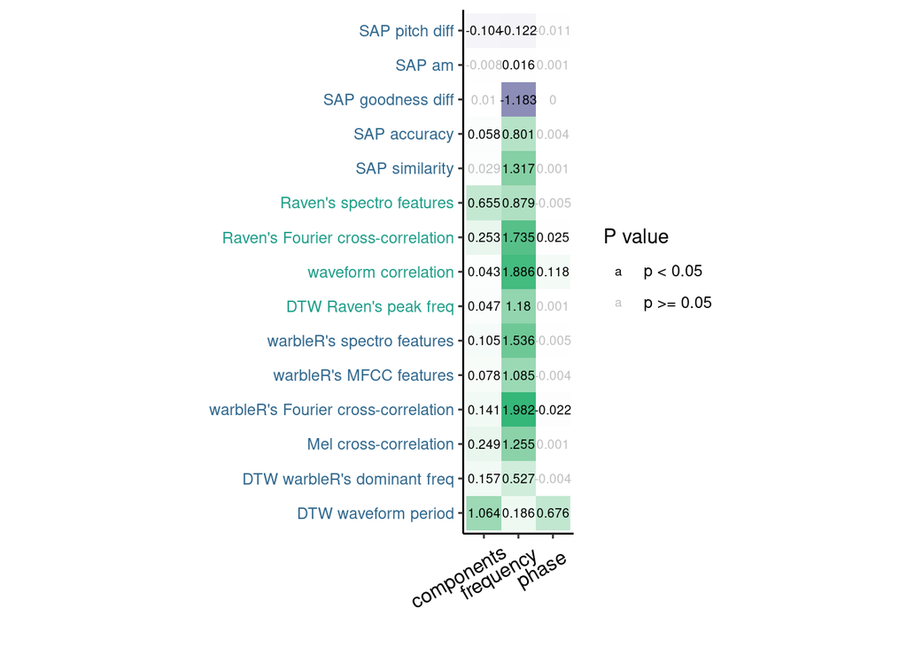

```r
mods <- list(dtw_wv_mod = dtw_wv_mod, wrbl_mod = wrbl_mod, mfcc_wrbl_mod = mfcc_wrbl_mod,
    rav_mod = rav_mod, xc_mod = xc_mod, mxc_mod = mxc_mod, dtw_dom_mod = dtw_dom_mod,
    dtw_rav_peak_mod = dtw_rav_peak_mod, wav_cr_rav_mod = wav_cr_rav_mod,
    xc_rav_mod = xc_rav_mod, dist_sap_mod = dist_sap_mod, acc_sap_mod = acc_sap_mod,
    good_sap_mod = good_sap_mod, pitch_diff_mod = pitch_diff_mod,
    am_sap_mod = am_sap_mod)

names(mods) <- c("DTW waveform period", "warbleR's spectro features",
    "warbleR's MFCC features", "Raven's spectro features", "warbleR's Fourier cross-correlation",
    "Mel cross-correlation", "DTW warbleR's dominant freq", "DTW Raven's peak freq",
    "waveform correlation", "Raven's Fourier cross-correlation", "SAP similarity",
    "SAP accuracy", "SAP goodness diff", "SAP pitch diff", "SAP am")

estimates <- do.call(rbind, lapply(seq_along(mods), function(x) {
    Y <- data.frame(mods[[x]]$coef[-1, ])
    Y$rel_coef <- Y[, 1]/max(Y[, 1])
    Y$mod <- names(mods)[x]
    Y$predictor <- rownames(Y)
    names(Y) <- c("coef", "p", "rel_coef", "model", "predictor")
    return(Y)
}))

estimates$rel_coef <- ifelse(estimates$p < 0.05, estimates$rel_coef,
    0)
estimates$signif <- ifelse(estimates$p < 0.05, "p < 0.05", "p >= 0.05")

estimates$model <- factor(estimates$model, levels = rev(c("SAP pitch diff",
    "SAP am", "SAP goodness diff", "SAP accuracy", "SAP similarity",
    "Raven's spectro features", "Raven's Fourier cross-correlation",
    "waveform correlation", "DTW Raven's peak freq", "warbleR's spectro features",
    "warbleR's MFCC features", "warbleR's Fourier cross-correlation",
    "Mel cross-correlation", "DTW warbleR's dominant freq", "DTW waveform period")))

estimates$predictor <- gsub("sign", "phase", estimates$predictor)

ggplot(estimates, aes(x = predictor, y = model, fill = coef)) + geom_tile() +
    coord_equal() + scale_fill_gradient2(low = viridis(10)[3], high = viridis(10)[7],
    guide = "none") + geom_text(aes(label = round(coef, 3), color = signif),
    size = 2.5) + scale_color_manual(values = c("black", "gray")) +
    labs(x = "", y = "", color = "P value") + theme_classic() + theme(axis.text.x = element_text(color = "black",
    size = 11, angle = 30, vjust = 0.8, hjust = 0.8), axis.text.y = element_text(color = c(rep(viridis(10)[4],
    6), rep(viridis(10)[6], 4))))
```

## 6.17 Synthesize Shroeders with 2 repetitions

```r
est_schr <- readRDS("./data/processed/extended_selection_table_random_start_schroeders.RDS")

mean_schroeders <- warbleR:::pblapply_wrblr_int(cl = 20, seq_len(nrow(est_schr)),
    function(x) {
        wave <- read_wave(est_schr, index = x)
        seg <- try_na(mean_segment(wave, plot = FALSE, mean = FALSE,
            type = "ac", thinning = 1))

        return(seg)
    })


names(mean_schroeders) <- paste(est_schr$f0, est_schr$label, sep = "-")

sapply(mean_schroeders, nrow)

mean_schroeders <- mean_schroeders[!sapply(mean_schroeders, function(x) is.na(x[[1]][1]))]


mean_schroeders_list <- lapply(seq_len(length(mean_schroeders)), function(x) {
    data.frame(schroeder = names(mean_schroeders)[x], time = seq(0,
        1, length.out = nrow(mean_schroeders[[x]])), mean.amp = rowMeans(mean_schroeders[[x]]))
})

names(mean_schroeders_list) <- names(mean_schroeders)


file_names <- paste0(f_pad_zero(x = 1:length(mean_schroeders_list),
    width = 3), "_f0-", substr(names(mean_schroeders_list), 0, 3),
    "_ncomp-", sapply(strsplit(gsub("_n|_p", "", names(mean_schroeders_list)),
        "-"), "[[", 2), "_", ifelse(grepl("_p", names(mean_schroeders_list)),
        "pos", "neg"), ".wav")


out <- warbleR:::pblapply_wrblr_int(seq_along(mean_schroeders_list),
    function(x) {

        mean_shc <- mean_schroeders_list[[x]]$mean.amp

        # duplicate it
        mean_shc <- c(mean_shc, mean_shc)

        start_sine <- sine(freq = 100, duration = 44100)@left

        cut_start <- which.min(abs(start_sine[22051:44100] - mean_shc[1])) +
            22050

        start_sine <- start_sine[(cut_start - ((44100/4) - length(mean_shc) -
            1)):cut_start]

        # start_sine <- sine(freq = 100, duration = (44100 / 4)
        # - length(mean_shc))@left

        length(start_sine)

        end_sine <- sine(freq = 100, duration = 44100/2)@left

        cut_end <- which.min(abs(end_sine[1:1000] - mean_shc[length(mean_shc)]))

        end_sine <- end_sine[cut_end:((44100/4) + cut_end - 1)]

        out <- c(start_sine, mean_shc, end_sine)

        wave_obj <- tuneR::normalize(tuneR::Wave(out, samp.rate = 44100,
            bit = 16), unit = "16")

        writeWave(object = wave_obj, filename = file.path("./data/processed/2_repeats_schroeders",
            file_names[x]), extensible = FALSE)

    })


est_rep_schr <- readRDS("./data/processed/extended_selection_table_schroeders.RDS")

# fix start
est_schr <- warbleR::selection_table(whole.recs = TRUE, path = "./data/processed/2_repeats_schroeders",
    extended = TRUE, confirm.extended = FALSE)

est_schr$bottom.freq <- est_rep_schr$bottom.freq

est_schr$top.freq <- est_rep_schr$top.freq

est_schr$f0 <- gsub("f0-", "", sapply(strsplit(est_schr$sound.files,
    split = "_"), "[[", 2))

est_schr$label <- gsub("os.wav_1|eg.wav_1", "", sapply(strsplit(est_schr$sound.files,
    split = "ncomp-"), "[[", 2))

master <- master_sound_file(X = est_schr, file.name = "schroeder_master_2_repeats",
    dest.path = "./data/processed/", gap.duration = 0.8, cex = 14)

write.csv(master, "./data/processed/master_annotations_schroeders_2_repeats.csv",
    row.names = FALSE)

master$f0 <- c("start_marker", paste("f0", est_schr$f0), "")

master$label <- c("marker", est_schr$label, "marker")

Rraven::exp_raven(master, path = "./data/processed/", sound.file.path = "./data/processed/",
    file.name = "master_annotations_schroeders_2_repeats_raven")

warbleR::full_spectrograms(master, path = "./data/processed/", sxrow = duration(readWave("./data/processed/schroeder_master_2_repeats.wav"))/12,
    rows = 12, horizontal = TRUE, dest.path = "./data/processed",
    collevels = seq(-150, 0, 5), labels = "label", song = "f0", wl = 2000,
    suffix = "2_repeats")
```

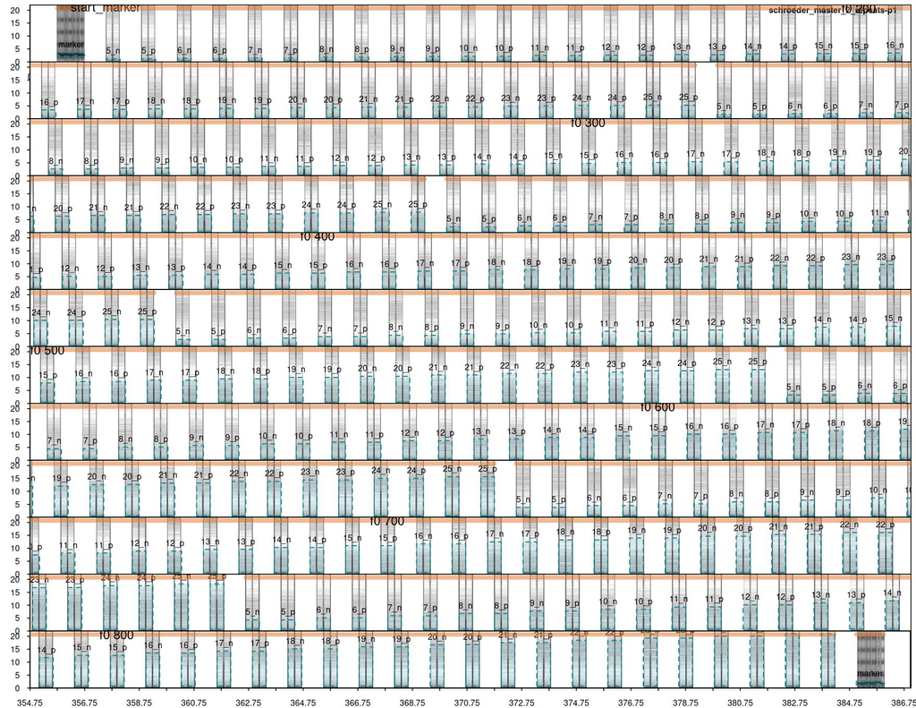

master sound file

# 7 Takeaways

- Amplitude autocorrelation works better at getting periodicity
- Dynamic time warping dissimilarity on mean periods, Raven’s waveform correlation and (to some extent) Fourier cross-correlation did capture phase differences in Schroeders
- Dynamic time warping dissimilarity on mean periods remove differences in frequency when forcing all periods to have the same number of values (i.e. same length)